# Investigate A Database

#### By: Ahmad Mohsen

#### November 2020

## Introduction

```
 - This project is about investigating an European soccer database that is in sqllite containing many tables like: Country', 'League', 'Player', 'Player Attributes', 'Team', 'Team Attributes' and 'Match', the database contains information about 11 european leagues between 2008 and 2016 and I shall practice what I have learnt about data wrangling, analysis then come up with conclusions and answers to questions related to this database using visulatizations with matplotlib
 The Questions I am going to ask are as follows:
    1- What teams improved the most over the time period?

    2- Which players had the most penalties?

    3- What team attributes lead to the most victories ?

    4- What player had the highest overall_rating in 2013?

    5- Which teams won the most games in the top 3 leagues in Europe?

    6-How much does the player attributes affect the overall rating?

    So Let's dig in!!
```

```python
# Import python libraries that will be used
import pandas as pd
import numpy as np
import matplotlib.pyplot as plt
import seaborn as sns
import sqlalchemy as sqla
%matplotlib inline
```

## Data Wrangling

#### - I shall start wrangling the database after importing it to the notebook using sqlalchemy library so I can manipulate the data and work with it through Pandas

```python
# Importing and reading the database
soccer_data = sqla.create_engine('sqlite:///database.sqlite')

# Assigning every table in a seperate dataframe
country_df = pd.read_sql('select * from Country', soccer_data)
match_df = pd.read_sql('select * from Match', soccer_data)
player_df = pd.read_sql('select * from Player', soccer_data)
playeratt_df = pd.read_sql('select * from Player_Attributes', soccer_data)
league_df = pd.read_sql('select * from League', soccer_data)
team_df = pd.read_sql('select * from Team', soccer_data)
teamatt_df = pd.read_sql('select * from Team_Attributes', soccer_data)
```

##### Visually observing the database

```python
match_df.head()
```

|  | id | country_id | league_id | season | stage | date | match_api_id | home_team_api_id | away_team_api_id | home_team_goal | ... | SJA | VCH | VCD | VCA | GBH | GBD | GBA | BSH | BSD | BSA |
| --- | --- | --- | --- | --- | --- | --- | --- | --- | --- | --- | --- | --- | --- | --- | --- | --- | --- | --- | --- | --- | --- |
| 0 | 1 | 1 | 1 | 2008/2009 | 1 | 2008-08-17 00:00:00 | 492473 | 9987 | 9993 | 1 | ... | 4.00 | 1.65 | 3.40 | 4.50 | 1.78 | 3.25 | 4.00 | 1.73 | 3.40 | 4.20 |
| 1 | 2 | 1 | 1 | 2008/2009 | 1 | 2008-08-16 00:00:00 | 492474 | 10000 | 9994 | 0 | ... | 3.80 | 2.00 | 3.25 | 3.25 | 1.85 | 3.25 | 3.75 | 1.91 | 3.25 | 3.60 |
| 2 | 3 | 1 | 1 | 2008/2009 | 1 | 2008-08-16 00:00:00 | 492475 | 9984 | 8635 | 0 | ... | 2.50 | 2.35 | 3.25 | 2.65 | 2.50 | 3.20 | 2.50 | 2.30 | 3.20 | 2.75 |
| 3 | 4 | 1 | 1 | 2008/2009 | 1 | 2008-08-17 00:00:00 | 492476 | 9991 | 9998 | 5 | ... | 7.50 | 1.45 | 3.75 | 6.50 | 1.50 | 3.75 | 5.50 | 1.44 | 3.75 | 6.50 |
| 4 | 5 | 1 | 1 | 2008/2009 | 1 | 2008-08-16 00:00:00 | 492477 | 7947 | 9985 | 1 | ... | 1.73 | 4.50 | 3.40 | 1.65 | 4.50 | 3.50 | 1.65 | 4.75 | 3.30 | 1.67 |

5 rows × 115 columns

```python
country_df.head()
```

|  | id | name |
| --- | --- | --- |
| 0 | 1 | Belgium |
| 1 | 1729 | England |
| 2 | 4769 | France |
| 3 | 7809 | Germany |
| 4 | 10257 | Italy |

```python
league_df.head()
```

|  | id | country_id | name |
| --- | --- | --- | --- |
| 0 | 1 | 1 | Belgium Jupiler League |
| 1 | 1729 | 1729 | England Premier League |
| 2 | 4769 | 4769 | France Ligue 1 |
| 3 | 7809 | 7809 | Germany 1. Bundesliga |
| 4 | 10257 | 10257 | Italy Serie A |

```python
player_df.head()
```

|  | id | player_api_id | player_name | player_fifa_api_id | birthday | height | weight |
| --- | --- | --- | --- | --- | --- | --- | --- |
| 0 | 1 | 505942 | Aaron Appindangoye | 218353 | 1992-02-29 00:00:00 | 182.88 | 187 |
| 1 | 2 | 155782 | Aaron Cresswell | 189615 | 1989-12-15 00:00:00 | 170.18 | 146 |
| 2 | 3 | 162549 | Aaron Doran | 186170 | 1991-05-13 00:00:00 | 170.18 | 163 |
| 3 | 4 | 30572 | Aaron Galindo | 140161 | 1982-05-08 00:00:00 | 182.88 | 198 |
| 4 | 5 | 23780 | Aaron Hughes | 17725 | 1979-11-08 00:00:00 | 182.88 | 154 |

```python
playeratt_df.head()
```

|  | id | player_fifa_api_id | player_api_id | date | overall_rating | potential | preferred_foot | attacking_work_rate | defensive_work_rate | crossing | ... | vision | penalties | marking | standing_tackle | sliding_tackle | gk_diving | gk_handling | gk_kicking | gk_positioning | gk_reflexes |
| --- | --- | --- | --- | --- | --- | --- | --- | --- | --- | --- | --- | --- | --- | --- | --- | --- | --- | --- | --- | --- | --- |
| 0 | 1 | 218353 | 505942 | 2016-02-18 00:00:00 | 67.0 | 71.0 | right | medium | medium | 49.0 | ... | 54.0 | 48.0 | 65.0 | 69.0 | 69.0 | 6.0 | 11.0 | 10.0 | 8.0 | 8.0 |
| 1 | 2 | 218353 | 505942 | 2015-11-19 00:00:00 | 67.0 | 71.0 | right | medium | medium | 49.0 | ... | 54.0 | 48.0 | 65.0 | 69.0 | 69.0 | 6.0 | 11.0 | 10.0 | 8.0 | 8.0 |
| 2 | 3 | 218353 | 505942 | 2015-09-21 00:00:00 | 62.0 | 66.0 | right | medium | medium | 49.0 | ... | 54.0 | 48.0 | 65.0 | 66.0 | 69.0 | 6.0 | 11.0 | 10.0 | 8.0 | 8.0 |
| 3 | 4 | 218353 | 505942 | 2015-03-20 00:00:00 | 61.0 | 65.0 | right | medium | medium | 48.0 | ... | 53.0 | 47.0 | 62.0 | 63.0 | 66.0 | 5.0 | 10.0 | 9.0 | 7.0 | 7.0 |
| 4 | 5 | 218353 | 505942 | 2007-02-22 00:00:00 | 61.0 | 65.0 | right | medium | medium | 48.0 | ... | 53.0 | 47.0 | 62.0 | 63.0 | 66.0 | 5.0 | 10.0 | 9.0 | 7.0 | 7.0 |

5 rows × 42 columns

```python
team_df.head()
```

|  | id | team_api_id | team_fifa_api_id | team_long_name | team_short_name |
| --- | --- | --- | --- | --- | --- |
| 0 | 1 | 9987 | 673.0 | KRC Genk | GEN |
| 1 | 2 | 9993 | 675.0 | Beerschot AC | BAC |
| 2 | 3 | 10000 | 15005.0 | SV Zulte-Waregem | ZUL |
| 3 | 4 | 9994 | 2007.0 | Sporting Lokeren | LOK |
| 4 | 5 | 9984 | 1750.0 | KSV Cercle Brugge | CEB |

```python
teamatt_df.head()
```

|  | id | team_fifa_api_id | team_api_id | date | buildUpPlaySpeed | buildUpPlaySpeedClass | buildUpPlayDribbling | buildUpPlayDribblingClass | buildUpPlayPassing | buildUpPlayPassingClass | ... | chanceCreationShooting | chanceCreationShootingClass | chanceCreationPositioningClass | defencePressure | defencePressureClass | defenceAggression | defenceAggressionClass | defenceTeamWidth | defenceTeamWidthClass | defenceDefenderLineClass |
| --- | --- | --- | --- | --- | --- | --- | --- | --- | --- | --- | --- | --- | --- | --- | --- | --- | --- | --- | --- | --- | --- |
| 0 | 1 | 434 | 9930 | 2010-02-22 00:00:00 | 60 | Balanced | NaN | Little | 50 | Mixed | ... | 55 | Normal | Organised | 50 | Medium | 55 | Press | 45 | Normal | Cover |
| 1 | 2 | 434 | 9930 | 2014-09-19 00:00:00 | 52 | Balanced | 48.0 | Normal | 56 | Mixed | ... | 64 | Normal | Organised | 47 | Medium | 44 | Press | 54 | Normal | Cover |
| 2 | 3 | 434 | 9930 | 2015-09-10 00:00:00 | 47 | Balanced | 41.0 | Normal | 54 | Mixed | ... | 64 | Normal | Organised | 47 | Medium | 44 | Press | 54 | Normal | Cover |
| 3 | 4 | 77 | 8485 | 2010-02-22 00:00:00 | 70 | Fast | NaN | Little | 70 | Long | ... | 70 | Lots | Organised | 60 | Medium | 70 | Double | 70 | Wide | Cover |
| 4 | 5 | 77 | 8485 | 2011-02-22 00:00:00 | 47 | Balanced | NaN | Little | 52 | Mixed | ... | 52 | Normal | Organised | 47 | Medium | 47 | Press | 52 | Normal | Cover |

5 rows × 25 columns

##### After visually observing the tables we will do the follwing:

```
1- Checking for duplicates and remvoing them
2- Dropping any NaNs if not necessary
3- Changing data types accordingly
4- Get rid of unnecessary columns
5- Preparing a clean wrangled match dataset
6- Merging Player table with player attributes table through the foreign key = 'player_api_id'
7- Merging Team table with team attributes table through the foreign key = 'team_api_id'
```

```python
match_df.duplicated().sum()
```

```
0
```

```python
match_df.isnull().sum()
```

```
id                0
country_id        0
league_id         0
season            0
stage             0
              ...
GBD           11817
GBA           11817
BSH           11818
BSD           11818
BSA           11818
Length: 115, dtype: int64
```

```python
# Droping all columns that has NaN values
match_df.dropna(axis = 'columns', inplace = True)
```

```python
#checking
match_df.isnull().sum()
```

```
id                  0
country_id          0
league_id           0
season              0
stage               0
date                0
match_api_id        0
home_team_api_id    0
away_team_api_id    0
home_team_goal      0
away_team_goal      0
dtype: int64
```

```python
match_df.info()
```

```
<class 'pandas.core.frame.DataFrame'>
RangeIndex: 25979 entries, 0 to 25978
Data columns (total 11 columns):
 #   Column            Non-Null Count  Dtype
---  ------            --------------  -----
 0   id                25979 non-null  int64
 1   country_id        25979 non-null  int64
 2   league_id         25979 non-null  int64
 3   season            25979 non-null  object
 4   stage             25979 non-null  int64
 5   date              25979 non-null  object
 6   match_api_id      25979 non-null  int64
 7   home_team_api_id  25979 non-null  int64
 8   away_team_api_id  25979 non-null  int64
 9   home_team_goal    25979 non-null  int64
 10  away_team_goal    25979 non-null  int64
dtypes: int64(9), object(2)
memory usage: 2.2+ MB
```

```python
# changing the date data type to datetime data type
match_df['date'] = pd.to_datetime(match_df['date'])
```

```python
match_df.info()
```

```
<class 'pandas.core.frame.DataFrame'>
RangeIndex: 25979 entries, 0 to 25978
Data columns (total 11 columns):
 #   Column            Non-Null Count  Dtype
---  ------            --------------  -----
 0   id                25979 non-null  int64
 1   country_id        25979 non-null  int64
 2   league_id         25979 non-null  int64
 3   season            25979 non-null  object
 4   stage             25979 non-null  int64
 5   date              25979 non-null  datetime64[ns]
 6   match_api_id      25979 non-null  int64
 7   home_team_api_id  25979 non-null  int64
 8   away_team_api_id  25979 non-null  int64
 9   home_team_goal    25979 non-null  int64
 10  away_team_goal    25979 non-null  int64
dtypes: datetime64[ns](1), int64(9), object(1)
memory usage: 2.2+ MB
```

```python
# starting merging
#adjusting columns names to match both tables
country_df.rename(columns={'name' : 'country_name', 'id' : 'country_id'}, inplace=True)

#applying inner merging between match and country tables
match_df = match_df.merge(country_df, how = 'inner', left_on = 'country_id', right_on = 'country_id')

match_df.drop(columns=['country_id'], inplace=True)
```

```python
#checking
match_df.head()
```

|  | id | league_id | season | stage | date | match_api_id | home_team_api_id | away_team_api_id | home_team_goal | away_team_goal | country_name |
| --- | --- | --- | --- | --- | --- | --- | --- | --- | --- | --- | --- |
| 0 | 1 | 1 | 2008/2009 | 1 | 2008-08-17 | 492473 | 9987 | 9993 | 1 | 1 | Belgium |
| 1 | 2 | 1 | 2008/2009 | 1 | 2008-08-16 | 492474 | 10000 | 9994 | 0 | 0 | Belgium |
| 2 | 3 | 1 | 2008/2009 | 1 | 2008-08-16 | 492475 | 9984 | 8635 | 0 | 3 | Belgium |
| 3 | 4 | 1 | 2008/2009 | 1 | 2008-08-17 | 492476 | 9991 | 9998 | 5 | 0 | Belgium |
| 4 | 5 | 1 | 2008/2009 | 1 | 2008-08-16 | 492477 | 7947 | 9985 | 1 | 3 | Belgium |

```python
#merging league table after modifiying with the merged match_df
league_df_copy = league_df.copy()

#renaming
league_df_copy.rename(columns={'name' : 'league_name', 'id' : 'league_id'}, inplace=True)

# #applying inner merge
match_df = match_df.merge(league_df_copy, how = 'inner', left_on = 'league_id', right_on = 'league_id')

match_df.drop(columns=['league_id'], inplace=True)
```

```python
#checking
match_df.head()
```

|  | id | season | stage | date | match_api_id | home_team_api_id | away_team_api_id | home_team_goal | away_team_goal | country_name | country_id | league_name |
| --- | --- | --- | --- | --- | --- | --- | --- | --- | --- | --- | --- | --- |
| 0 | 1 | 2008/2009 | 1 | 2008-08-17 | 492473 | 9987 | 9993 | 1 | 1 | Belgium | 1 | Belgium Jupiler League |
| 1 | 2 | 2008/2009 | 1 | 2008-08-16 | 492474 | 10000 | 9994 | 0 | 0 | Belgium | 1 | Belgium Jupiler League |
| 2 | 3 | 2008/2009 | 1 | 2008-08-16 | 492475 | 9984 | 8635 | 0 | 3 | Belgium | 1 | Belgium Jupiler League |
| 3 | 4 | 2008/2009 | 1 | 2008-08-17 | 492476 | 9991 | 9998 | 5 | 0 | Belgium | 1 | Belgium Jupiler League |
| 4 | 5 | 2008/2009 | 1 | 2008-08-16 | 492477 | 7947 | 9985 | 1 | 3 | Belgium | 1 | Belgium Jupiler League |

```python
#modifying team table to merge it with the main match table (2 times merging)
team_df_copy = team_df.copy()

#dropping unnecessary columns
team_df_copy.drop(columns = [ 'id', 'team_fifa_api_id', 'team_short_name'], axis = 1, inplace=True)
#checking
team_df_copy.head()
```

|  | team_api_id | team_long_name |
| --- | --- | --- |
| 0 | 9987 | KRC Genk |
| 1 | 9993 | Beerschot AC |
| 2 | 10000 | SV Zulte-Waregem |
| 3 | 9994 | Sporting Lokeren |
| 4 | 9984 | KSV Cercle Brugge |

```python
# #merging with home_team_api_id

match_df = match_df.merge(team_df_copy, how = 'inner', left_on = 'home_team_api_id', right_on = 'team_api_id')

# # dropping and modifiying
match_df.rename(columns={'team_long_name': 'home_team_name'}, inplace=True)

match_df.drop(columns=['home_team_api_id', 'team_api_id'], axis=1, inplace=True)

# #merging with away_team_api_id
match_df = match_df.merge(team_df_copy, how = 'left', left_on = 'away_team_api_id', right_on = 'team_api_id')

# #dropping and modifiying
match_df.rename(columns={'team_long_name': 'away_team_name'}, inplace=True)

match_df.drop(columns=['away_team_api_id', 'country_id', 'team_api_id'], inplace=True)
```

```python
#checking
match_df.head()
```

|  | id | season | stage | date | match_api_id | home_team_goal | away_team_goal | country_name | league_name | home_team_name | away_team_name |
| --- | --- | --- | --- | --- | --- | --- | --- | --- | --- | --- | --- |
| 0 | 1 | 2008/2009 | 1 | 2008-08-17 | 492473 | 1 | 1 | Belgium | Belgium Jupiler League | KRC Genk | Beerschot AC |
| 1 | 29 | 2008/2009 | 12 | 2008-11-15 | 492583 | 1 | 1 | Belgium | Belgium Jupiler League | KRC Genk | KSV Roeselare |
| 2 | 47 | 2008/2009 | 14 | 2008-11-29 | 492651 | 3 | 2 | Belgium | Belgium Jupiler League | KRC Genk | KSV Cercle Brugge |
| 3 | 65 | 2008/2009 | 16 | 2008-12-13 | 492713 | 1 | 0 | Belgium | Belgium Jupiler League | KRC Genk | Sporting Charleroi |
| 4 | 94 | 2008/2009 | 19 | 2009-01-24 | 492805 | 2 | 0 | Belgium | Belgium Jupiler League | KRC Genk | RAEC Mons |

```python
#Adding a column for match winner
def winner(row):
    home_score = row[0]
    away_score = row[1]
    home_team_name = row[2]
    away_team_name = row[3]

    if home_score > away_score:
        return home_team_name
    elif home_score < away_score:
        return away_team_name
    else:
        return 'Draw'
match_df['winner']  = match_df[['home_team_goal', 'away_team_goal', 'home_team_name', 'away_team_name']].apply(winner, axis=1)
```

```python
match_df.head()
```

|  | id | season | stage | date | match_api_id | home_team_goal | away_team_goal | country_name | league_name | home_team_name | away_team_name | winner |
| --- | --- | --- | --- | --- | --- | --- | --- | --- | --- | --- | --- | --- |
| 0 | 1 | 2008/2009 | 1 | 2008-08-17 | 492473 | 1 | 1 | Belgium | Belgium Jupiler League | KRC Genk | Beerschot AC | Draw |
| 1 | 29 | 2008/2009 | 12 | 2008-11-15 | 492583 | 1 | 1 | Belgium | Belgium Jupiler League | KRC Genk | KSV Roeselare | Draw |
| 2 | 47 | 2008/2009 | 14 | 2008-11-29 | 492651 | 3 | 2 | Belgium | Belgium Jupiler League | KRC Genk | KSV Cercle Brugge | KRC Genk |
| 3 | 65 | 2008/2009 | 16 | 2008-12-13 | 492713 | 1 | 0 | Belgium | Belgium Jupiler League | KRC Genk | Sporting Charleroi | KRC Genk |
| 4 | 94 | 2008/2009 | 19 | 2009-01-24 | 492805 | 2 | 0 | Belgium | Belgium Jupiler League | KRC Genk | RAEC Mons | KRC Genk |

```python
#Adding a column for points
def points(row):
    home_score = row[0]
    away_score = row[1]
    home_team_name = row[2]
    away_team_name = row[3]

    if home_score > away_score:
        return ('{} gained 3 points'.format(home_team_name))
    elif home_score < away_score:
        return ('{} gained 3 points'.format(away_team_name))
    else:
        return ('{} and {} gained 1 point'.format(home_team_name, away_team_name))
match_df['points_indicator']  = match_df[['home_team_goal', 'away_team_goal', 'home_team_name', 'away_team_name']].apply(points, axis=1)
```

```python
match_df.head()
```

|  | id | season | stage | date | match_api_id | home_team_goal | away_team_goal | country_name | league_name | home_team_name | away_team_name | winner | points_indicator |
| --- | --- | --- | --- | --- | --- | --- | --- | --- | --- | --- | --- | --- | --- |
| 0 | 1 | 2008/2009 | 1 | 2008-08-17 | 492473 | 1 | 1 | Belgium | Belgium Jupiler League | KRC Genk | Beerschot AC | Draw | KRC Genk and Beerschot AC gained 1 point |
| 1 | 29 | 2008/2009 | 12 | 2008-11-15 | 492583 | 1 | 1 | Belgium | Belgium Jupiler League | KRC Genk | KSV Roeselare | Draw | KRC Genk and KSV Roeselare gained 1 point |
| 2 | 47 | 2008/2009 | 14 | 2008-11-29 | 492651 | 3 | 2 | Belgium | Belgium Jupiler League | KRC Genk | KSV Cercle Brugge | KRC Genk | KRC Genk gained 3 points |
| 3 | 65 | 2008/2009 | 16 | 2008-12-13 | 492713 | 1 | 0 | Belgium | Belgium Jupiler League | KRC Genk | Sporting Charleroi | KRC Genk | KRC Genk gained 3 points |
| 4 | 94 | 2008/2009 | 19 | 2009-01-24 | 492805 | 2 | 0 | Belgium | Belgium Jupiler League | KRC Genk | RAEC Mons | KRC Genk | KRC Genk gained 3 points |

```python
#dropping unnecessary columns
match_df.drop(columns=['stage', 'match_api_id'], inplace=True)
```

```python
match_df.head()
```

|  | id | season | date | home_team_goal | away_team_goal | country_name | league_name | home_team_name | away_team_name | winner | points_indicator |
| --- | --- | --- | --- | --- | --- | --- | --- | --- | --- | --- | --- |
| 0 | 1 | 2008/2009 | 2008-08-17 | 1 | 1 | Belgium | Belgium Jupiler League | KRC Genk | Beerschot AC | Draw | KRC Genk and Beerschot AC gained 1 point |
| 1 | 29 | 2008/2009 | 2008-11-15 | 1 | 1 | Belgium | Belgium Jupiler League | KRC Genk | KSV Roeselare | Draw | KRC Genk and KSV Roeselare gained 1 point |
| 2 | 47 | 2008/2009 | 2008-11-29 | 3 | 2 | Belgium | Belgium Jupiler League | KRC Genk | KSV Cercle Brugge | KRC Genk | KRC Genk gained 3 points |
| 3 | 65 | 2008/2009 | 2008-12-13 | 1 | 0 | Belgium | Belgium Jupiler League | KRC Genk | Sporting Charleroi | KRC Genk | KRC Genk gained 3 points |
| 4 | 94 | 2008/2009 | 2009-01-24 | 2 | 0 | Belgium | Belgium Jupiler League | KRC Genk | RAEC Mons | KRC Genk | KRC Genk gained 3 points |

```python
#saving the matches dataset after wrangling
match_df.to_csv('matches_dataset_wrangled.csv', index=False)
```

### Working on team and team_attributes tables

```python
team_df.team_long_name.value_counts()
```

```
Polonia Bytom           2
Widzew Łódź             2
Royal Excel Mouscron    2
FC Porto                1
SV Zulte-Waregem        1
                       ..
Toulouse FC             1
Lugano                  1
Sparta Rotterdam        1
FC Aarau                1
Cagliari                1
Name: team_long_name, Length: 296, dtype: int64
```

##### as we can see there are some repeated clubs names which isn't acceptable

```python
team_df.query('team_long_name == "Royal Excel Mouscron"')
```

|  | id | team_api_id | team_fifa_api_id | team_long_name | team_short_name |
| --- | --- | --- | --- | --- | --- |
| 15 | 16 | 9996 | 111560.0 | Royal Excel Mouscron | MOU |
| 24 | 2510 | 274581 | 111560.0 | Royal Excel Mouscron | MOP |

```python
team_df.query('team_long_name == "Polonia Bytom"')
```

|  | id | team_api_id | team_fifa_api_id | team_long_name | team_short_name |
| --- | --- | --- | --- | --- | --- |
| 182 | 31444 | 8031 | 111429.0 | Polonia Bytom | POB |
| 183 | 31445 | 8020 | 111429.0 | Polonia Bytom | GOR |

```python
team_df.query('team_long_name == "Widzew Łódź"')
```

|  | id | team_api_id | team_fifa_api_id | team_long_name | team_short_name |
| --- | --- | --- | --- | --- | --- |
| 189 | 31451 | 8244 | 301.0 | Widzew Łódź | LOD |
| 199 | 32409 | 8024 | 301.0 | Widzew Łódź | WID |

##### Dropping any repeated team names

```python
team_df.drop(index=[15, 182, 189], inplace=True)
```

```python
#checking
team_df.team_long_name.value_counts()
```

```
Stade de Reims      1
Roda JC Kerkrade    1
SV Zulte-Waregem    1
Pescara             1
FC Basel            1
                   ..
Toulouse FC         1
Lugano              1
Sparta Rotterdam    1
FC Aarau            1
Cagliari            1
Name: team_long_name, Length: 296, dtype: int64
```

### Performing merge between team and team_attributes tables

```python
#Performing merge between team and team_attributes tables
team_att_df = teamatt_df.merge(team_df, left_on = 'team_api_id', right_on = 'team_api_id')
```

```python
team_att_df.head()
```

|  | id_x | team_fifa_api_id_x | team_api_id | date | buildUpPlaySpeed | buildUpPlaySpeedClass | buildUpPlayDribbling | buildUpPlayDribblingClass | buildUpPlayPassing | buildUpPlayPassingClass | ... | defencePressureClass | defenceAggression | defenceAggressionClass | defenceTeamWidth | defenceTeamWidthClass | defenceDefenderLineClass | id_y | team_fifa_api_id_y | team_long_name | team_short_name |
| --- | --- | --- | --- | --- | --- | --- | --- | --- | --- | --- | --- | --- | --- | --- | --- | --- | --- | --- | --- | --- | --- |
| 0 | 1 | 434 | 9930 | 2010-02-22 00:00:00 | 60 | Balanced | NaN | Little | 50 | Mixed | ... | Medium | 55 | Press | 45 | Normal | Cover | 49119 | 434.0 | FC Aarau | AAR |
| 1 | 2 | 434 | 9930 | 2014-09-19 00:00:00 | 52 | Balanced | 48.0 | Normal | 56 | Mixed | ... | Medium | 44 | Press | 54 | Normal | Cover | 49119 | 434.0 | FC Aarau | AAR |
| 2 | 3 | 434 | 9930 | 2015-09-10 00:00:00 | 47 | Balanced | 41.0 | Normal | 54 | Mixed | ... | Medium | 44 | Press | 54 | Normal | Cover | 49119 | 434.0 | FC Aarau | AAR |
| 3 | 4 | 77 | 8485 | 2010-02-22 00:00:00 | 70 | Fast | NaN | Little | 70 | Long | ... | Medium | 70 | Double | 70 | Wide | Cover | 39393 | 77.0 | Aberdeen | ABE |
| 4 | 5 | 77 | 8485 | 2011-02-22 00:00:00 | 47 | Balanced | NaN | Little | 52 | Mixed | ... | Medium | 47 | Press | 52 | Normal | Cover | 39393 | 77.0 | Aberdeen | ABE |

5 rows × 29 columns

```python
#modifying columns after merging
#dropping unnecessary columns
team_att_df.drop(columns=['id_y', 'team_fifa_api_id_y', 'team_fifa_api_id_x'], inplace=True)

#renaming columns that were affected by merging
team_att_df.rename(columns={'id_x' : 'id'}, inplace=True)
```

```python
#checking
team_att_df.head()
```

|  | id | team_api_id | date | buildUpPlaySpeed | buildUpPlaySpeedClass | buildUpPlayDribbling | buildUpPlayDribblingClass | buildUpPlayPassing | buildUpPlayPassingClass | buildUpPlayPositioningClass | ... | chanceCreationPositioningClass | defencePressure | defencePressureClass | defenceAggression | defenceAggressionClass | defenceTeamWidth | defenceTeamWidthClass | defenceDefenderLineClass | team_long_name | team_short_name |
| --- | --- | --- | --- | --- | --- | --- | --- | --- | --- | --- | --- | --- | --- | --- | --- | --- | --- | --- | --- | --- | --- |
| 0 | 1 | 9930 | 2010-02-22 00:00:00 | 60 | Balanced | NaN | Little | 50 | Mixed | Organised | ... | Organised | 50 | Medium | 55 | Press | 45 | Normal | Cover | FC Aarau | AAR |
| 1 | 2 | 9930 | 2014-09-19 00:00:00 | 52 | Balanced | 48.0 | Normal | 56 | Mixed | Organised | ... | Organised | 47 | Medium | 44 | Press | 54 | Normal | Cover | FC Aarau | AAR |
| 2 | 3 | 9930 | 2015-09-10 00:00:00 | 47 | Balanced | 41.0 | Normal | 54 | Mixed | Organised | ... | Organised | 47 | Medium | 44 | Press | 54 | Normal | Cover | FC Aarau | AAR |
| 3 | 4 | 8485 | 2010-02-22 00:00:00 | 70 | Fast | NaN | Little | 70 | Long | Organised | ... | Organised | 60 | Medium | 70 | Double | 70 | Wide | Cover | Aberdeen | ABE |
| 4 | 5 | 8485 | 2011-02-22 00:00:00 | 47 | Balanced | NaN | Little | 52 | Mixed | Organised | ... | Organised | 47 | Medium | 47 | Press | 52 | Normal | Cover | Aberdeen | ABE |

5 rows × 26 columns

```python
#checking that datatypes are okay
team_att_df.info()
```

```
<class 'pandas.core.frame.DataFrame'>
Int64Index: 1450 entries, 0 to 1449
Data columns (total 26 columns):
 #   Column                          Non-Null Count  Dtype
---  ------                          --------------  -----
 0   id                              1450 non-null   int64
 1   team_api_id                     1450 non-null   int64
 2   date                            1450 non-null   object
 3   buildUpPlaySpeed                1450 non-null   int64
 4   buildUpPlaySpeedClass           1450 non-null   object
 5   buildUpPlayDribbling            486 non-null    float64
 6   buildUpPlayDribblingClass       1450 non-null   object
 7   buildUpPlayPassing              1450 non-null   int64
 8   buildUpPlayPassingClass         1450 non-null   object
 9   buildUpPlayPositioningClass     1450 non-null   object
```

[output cut: 18 more lines]

```python
#some datatypes need to be changed
team_att_df['date'] = pd.to_datetime(team_att_df['date'])

#checking
team_att_df.info()
```

```
<class 'pandas.core.frame.DataFrame'>
Int64Index: 1450 entries, 0 to 1449
Data columns (total 26 columns):
 #   Column                          Non-Null Count  Dtype
---  ------                          --------------  -----
 0   id                              1450 non-null   int64
 1   team_api_id                     1450 non-null   int64
 2   date                            1450 non-null   datetime64[ns]
 3   buildUpPlaySpeed                1450 non-null   int64
 4   buildUpPlaySpeedClass           1450 non-null   object
 5   buildUpPlayDribbling            486 non-null    float64
 6   buildUpPlayDribblingClass       1450 non-null   object
 7   buildUpPlayPassing              1450 non-null   int64
 8   buildUpPlayPassingClass         1450 non-null   object
 9   buildUpPlayPositioningClass     1450 non-null   object
```

[output cut: 18 more lines]

```python
#all is good, let's save the dataset
team_att_df.to_csv('merged_team_attributes.csv', index=False)
```

```python
player_df.player_fifa_api_id.duplicated().value_counts()
```

```
False    11060
Name: player_fifa_api_id, dtype: int64
```

#### Luckily we don't have any duplicated players

### Performing merge between player and player_attributes tables

```python
#Performing merge between team and team_attributes tables
player_att_df = playeratt_df.merge(player_df, left_on = 'player_api_id', right_on = 'player_api_id')
```

```python
#checking
player_att_df.head()
```

|  | id_x | player_fifa_api_id_x | player_api_id | date | overall_rating | potential | preferred_foot | attacking_work_rate | defensive_work_rate | crossing | ... | gk_handling | gk_kicking | gk_positioning | gk_reflexes | id_y | player_name | player_fifa_api_id_y | birthday | height | weight |
| --- | --- | --- | --- | --- | --- | --- | --- | --- | --- | --- | --- | --- | --- | --- | --- | --- | --- | --- | --- | --- | --- |
| 0 | 1 | 218353 | 505942 | 2016-02-18 00:00:00 | 67.0 | 71.0 | right | medium | medium | 49.0 | ... | 11.0 | 10.0 | 8.0 | 8.0 | 1 | Aaron Appindangoye | 218353 | 1992-02-29 00:00:00 | 182.88 | 187 |
| 1 | 2 | 218353 | 505942 | 2015-11-19 00:00:00 | 67.0 | 71.0 | right | medium | medium | 49.0 | ... | 11.0 | 10.0 | 8.0 | 8.0 | 1 | Aaron Appindangoye | 218353 | 1992-02-29 00:00:00 | 182.88 | 187 |
| 2 | 3 | 218353 | 505942 | 2015-09-21 00:00:00 | 62.0 | 66.0 | right | medium | medium | 49.0 | ... | 11.0 | 10.0 | 8.0 | 8.0 | 1 | Aaron Appindangoye | 218353 | 1992-02-29 00:00:00 | 182.88 | 187 |
| 3 | 4 | 218353 | 505942 | 2015-03-20 00:00:00 | 61.0 | 65.0 | right | medium | medium | 48.0 | ... | 10.0 | 9.0 | 7.0 | 7.0 | 1 | Aaron Appindangoye | 218353 | 1992-02-29 00:00:00 | 182.88 | 187 |
| 4 | 5 | 218353 | 505942 | 2007-02-22 00:00:00 | 61.0 | 65.0 | right | medium | medium | 48.0 | ... | 10.0 | 9.0 | 7.0 | 7.0 | 1 | Aaron Appindangoye | 218353 | 1992-02-29 00:00:00 | 182.88 | 187 |

5 rows × 48 columns

```python
#dropping unnecessary columns
player_att_df.drop(columns=['id_y', 'player_fifa_api_id_y', 'player_fifa_api_id_x'], inplace=True)

#renaming columns that were affected by merging
player_att_df.rename(columns={'id_x' : 'id'}, inplace=True)
```

```python
#checking datatypes
player_att_df.info()
```

```
<class 'pandas.core.frame.DataFrame'>
Int64Index: 183978 entries, 0 to 183977
Data columns (total 45 columns):
 #   Column               Non-Null Count   Dtype
---  ------               --------------   -----
 0   id                   183978 non-null  int64
 1   player_api_id        183978 non-null  int64
 2   date                 183978 non-null  object
 3   overall_rating       183142 non-null  float64
 4   potential            183142 non-null  float64
 5   preferred_foot       183142 non-null  object
 6   attacking_work_rate  180748 non-null  object
 7   defensive_work_rate  183142 non-null  object
 8   crossing             183142 non-null  float64
 9   finishing            183142 non-null  float64
```

[output cut: 37 more lines]

```python
#some datatypes need to be changed
player_att_df['date'] = pd.to_datetime(player_att_df['date'])
player_att_df['birthday'] = pd.to_datetime(player_att_df['birthday'])

#checking
player_att_df.info()
```

```
<class 'pandas.core.frame.DataFrame'>
Int64Index: 183978 entries, 0 to 183977
Data columns (total 45 columns):
 #   Column               Non-Null Count   Dtype
---  ------               --------------   -----
 0   id                   183978 non-null  int64
 1   player_api_id        183978 non-null  int64
 2   date                 183978 non-null  datetime64[ns]
 3   overall_rating       183142 non-null  float64
 4   potential            183142 non-null  float64
 5   preferred_foot       183142 non-null  object
 6   attacking_work_rate  180748 non-null  object
 7   defensive_work_rate  183142 non-null  object
 8   crossing             183142 non-null  float64
 9   finishing            183142 non-null  float64
```

[output cut: 37 more lines]

```python
#all is good, let's save this dataset
player_att_df.to_csv('merged_player_attributes.csv', index=True)
```

# Data Analysis Part

### Answering Questions related to the database

```python
#importing the data we wrangled
matches = pd.read_csv('matches_dataset_wrangled.csv')
players = pd.read_csv('merged_player_attributes.csv')
teams = pd.read_csv('merged_team_attributes.csv')
```

### Q1 : What teams improved the most over the time period?

```python
#adding a column for each team total score
teams['total_team_score'] = teams['buildUpPlaySpeed'] + teams['buildUpPlayPassing'] + teams['chanceCreationPassing']
+ teams['chanceCreationCrossing'] + teams['chanceCreationShooting'] + teams['defencePressure']
+ teams['defenceAggression'] + teams['defenceTeamWidth']
```

```
0       100
1        98
2        98
3       140
4        99
       ...
1445    101
1446    108
1447     95
1448     95
1449     95
Length: 1450, dtype: int64
```

```python
#Extracting the year from the date into a sperate column
teams['year'] = pd.DatetimeIndex(teams['date']).year

#getting the teams stats in first and last year recorded in the dataset
teams_df_2010 = teams.query('year == 2010')

teams_df_2015 = teams.query('year == 2015')

teams_stats_2010 = teams_df_2010.groupby(['team_long_name'])['total_team_score'].mean()

teams_stats_2015 = teams_df_2015.groupby(['team_long_name'])['total_team_score'].mean()

stats = teams_stats_2015 - teams_stats_2010

stats.dropna(inplace=True)


sorted_stats = stats.sort_values(ascending=True).index

stats.sort_values(ascending=True)
```

```
team_long_name
St. Mirren            -86.0
Swansea City          -84.0
Bournemouth           -67.0
KAA Gent              -66.0
Queens Park Rangers   -66.0
                       ...
CS Marítimo            79.0
ADO Den Haag           82.0
West Ham United        83.0
Sassuolo               83.0
Levante UD             93.0
Name: total_team_score, Length: 206, dtype: float64
```

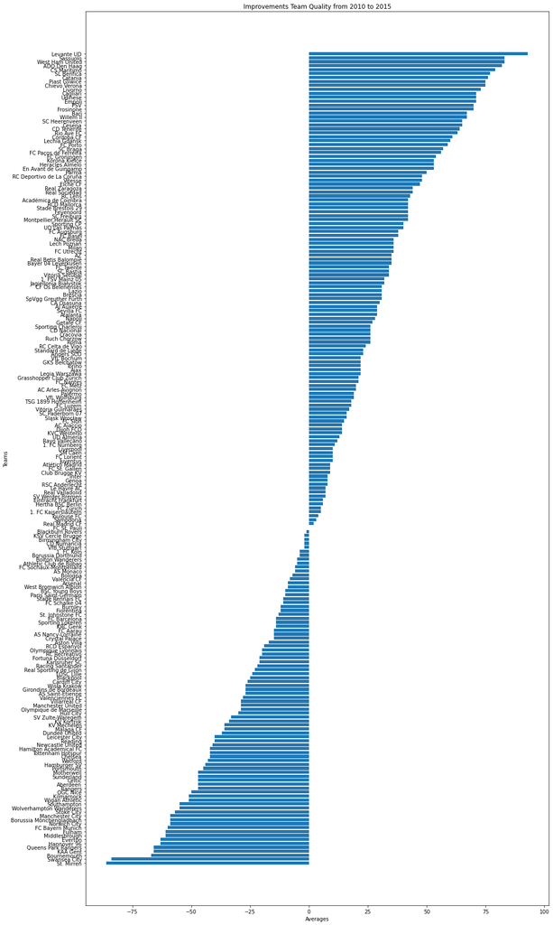

```python
#Plotting
fig, axs = plt.subplots(figsize=(15, 25))


# plot a horizontal bar
plt.barh(range(0,len(sorted_stats)), stats.sort_values())

# Set the position of the y ticks
axs.set_yticks(range(0,len(sorted_stats)))

# Set the position of the y ticks labels
axs.set_yticklabels(sorted_stats)


# Set the y axis label
axs.set_ylabel('Teams')


# Set the chart's title
axs.set_title('Improvements Team Quality from 2010 to 2015')

# Set the y axis label
plt.xlabel("Averages")

plt.tight_layout();
```

### Q2 : Which players had the most penalties?

```python
pp = player_att_df.groupby(['player_name', 'player_api_id'])['penalties'].sum().sort_values(ascending=False)[:8]

pp
```

```
player_name         player_api_id
Alessio Cerci       41269            4314.0
Mario Balotelli     108808           4120.0
Claudio Marchisio   41890            3984.0
Michael Bradley     26472            3813.0
Zdravko Kuzmanovic  25772            3799.0
Andrea Pirlo        30731            3791.0
Antonio Di Natale   27734            3767.0
Thierry Henry       30626            3712.0
Name: penalties, dtype: float64
```

### Q3 : What team attributes lead to the most victories ?

```python
matches['winner'].value_counts()[1:6]
```

```
FC Barcelona         234
Real Madrid CF       228
Celtic               218
FC Bayern Munich     193
Manchester United    192
Name: winner, dtype: int64
```

```python
team_att_df['year'] = pd.DatetimeIndex(team_att_df['date']).year

team_att_df.head()
```

|  | id | team_api_id | date | buildUpPlaySpeed | buildUpPlaySpeedClass | buildUpPlayDribbling | buildUpPlayDribblingClass | buildUpPlayPassing | buildUpPlayPassingClass | buildUpPlayPositioningClass | ... | defencePressure | defencePressureClass | defenceAggression | defenceAggressionClass | defenceTeamWidth | defenceTeamWidthClass | defenceDefenderLineClass | team_long_name | team_short_name | year |
| --- | --- | --- | --- | --- | --- | --- | --- | --- | --- | --- | --- | --- | --- | --- | --- | --- | --- | --- | --- | --- | --- |
| 0 | 1 | 9930 | 2010-02-22 | 60 | Balanced | NaN | Little | 50 | Mixed | Organised | ... | 50 | Medium | 55 | Press | 45 | Normal | Cover | FC Aarau | AAR | 2010 |
| 1 | 2 | 9930 | 2014-09-19 | 52 | Balanced | 48.0 | Normal | 56 | Mixed | Organised | ... | 47 | Medium | 44 | Press | 54 | Normal | Cover | FC Aarau | AAR | 2014 |
| 2 | 3 | 9930 | 2015-09-10 | 47 | Balanced | 41.0 | Normal | 54 | Mixed | Organised | ... | 47 | Medium | 44 | Press | 54 | Normal | Cover | FC Aarau | AAR | 2015 |
| 3 | 4 | 8485 | 2010-02-22 | 70 | Fast | NaN | Little | 70 | Long | Organised | ... | 60 | Medium | 70 | Double | 70 | Wide | Cover | Aberdeen | ABE | 2010 |
| 4 | 5 | 8485 | 2011-02-22 | 47 | Balanced | NaN | Little | 52 | Mixed | Organised | ... | 47 | Medium | 47 | Press | 52 | Normal | Cover | Aberdeen | ABE | 2011 |

5 rows × 27 columns

```python
#retrieving the most victorious team attributes in each year
team_att_df.drop(columns = ['id', 'team_api_id', 'date'],inplace=True)

barca = team_att_df.query('team_long_name == "FC Barcelona"')

barca_copy = barca.copy()

barca_copy.drop(columns=['year'], inplace=True)

barca_copy
```

|  | buildUpPlaySpeed | buildUpPlaySpeedClass | buildUpPlayDribbling | buildUpPlayDribblingClass | buildUpPlayPassing | buildUpPlayPassingClass | buildUpPlayPositioningClass | chanceCreationPassing | chanceCreationPassingClass | chanceCreationCrossing | ... | chanceCreationPositioningClass | defencePressure | defencePressureClass | defenceAggression | defenceAggressionClass | defenceTeamWidth | defenceTeamWidthClass | defenceDefenderLineClass | team_long_name | team_short_name |
| --- | --- | --- | --- | --- | --- | --- | --- | --- | --- | --- | --- | --- | --- | --- | --- | --- | --- | --- | --- | --- | --- |
| 118 | 42 | Balanced | NaN | Little | 30 | Short | Free Form | 65 | Normal | 40 | ... | Free Form | 70 | High | 30 | Contain | 70 | Wide | Offside Trap | FC Barcelona | BAR |
| 119 | 43 | Balanced | NaN | Little | 34 | Mixed | Free Form | 59 | Normal | 25 | ... | Free Form | 67 | High | 43 | Press | 68 | Wide | Cover | FC Barcelona | BAR |
| 120 | 24 | Slow | NaN | Little | 25 | Short | Free Form | 37 | Normal | 24 | ... | Free Form | 66 | Medium | 63 | Press | 66 | Normal | Cover | FC Barcelona | BAR |
| 121 | 35 | Balanced | NaN | Little | 32 | Short | Free Form | 37 | Normal | 31 | ... | Free Form | 61 | Medium | 63 | Press | 65 | Normal | Cover | FC Barcelona | BAR |
| 122 | 35 | Balanced | 35.0 | Normal | 32 | Short | Free Form | 37 | Normal | 31 | ... | Free Form | 61 | Medium | 63 | Press | 65 | Normal | Cover | FC Barcelona | BAR |
| 123 | 36 | Balanced | 35.0 | Normal | 51 | Mixed | Free Form | 36 | Normal | 49 | ... | Free Form | 61 | Medium | 65 | Press | 65 | Normal | Cover | FC Barcelona | BAR |

6 rows × 23 columns

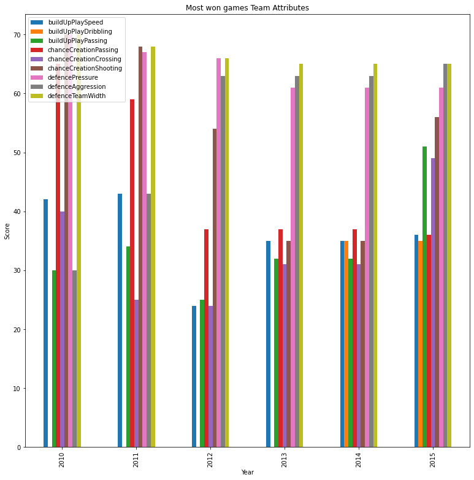

```python
fig , ax = plt.subplots(figsize=(13, 13))

ax = barca_copy.plot.bar(ax=ax);

ax.set_xticklabels(barca['year'], rotation=90)

# Set the y axis label
ax.set_ylabel('Score')

# Set the chart's title
ax.set_title('Most won games Team Attributes')

# Set the y axis label
plt.xlabel("Year")
```

### Q4 : What player had the highest overall_rating in 2013?

```python
#Extracting the year from the date into a sperate column
players['year'] = pd.DatetimeIndex(players['date']).year

highest_players = players.query('year == 2013').groupby(['year', 'player_name'])['overall_rating'].mean().sort_values(ascending=False)[:5]

highest_players
```

```
year  player_name
2013  Lionel Messi         94.00
      Cristiano Ronaldo    92.00
      Radamel Falcao       90.00
      Franck Ribery        90.00
      Andres Iniesta       89.75
Name: overall_rating, dtype: float64
```

### Q5 : Which teams won the most games in the top 3 leagues in Europe?

```python
england = matches.query('country_name == "England"')

top_teams_england = england['winner'].value_counts()[1:4]

tte = top_teams_england.index
```

```python
spain = matches.query('country_name == "Spain"')

top_teams_spain = spain['winner'].value_counts()[1:4]

tts = top_teams_spain.index
```

```python
italy = matches.query('country_name == "Italy"')

top_teams_italy = italy['winner'].value_counts()[1:4]

tti = top_teams_italy.index
```

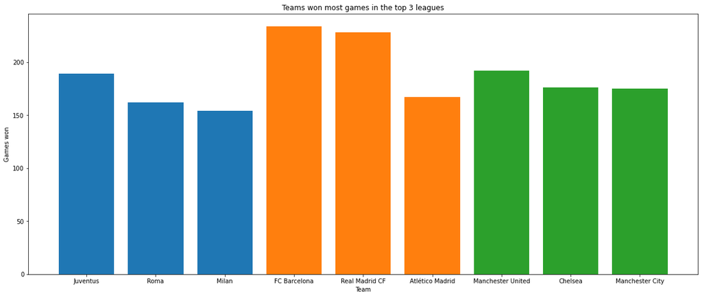

```python
fig, ax = plt.subplots(figsize=(20,8))

ax.bar(tti, top_teams_italy)

ax.bar(tts, top_teams_spain)

ax.bar(tte, top_teams_england)

plt.title('Teams won most games in the top 3 leagues')

plt.xlabel('Team')

plt.ylabel('Games won')

plt.show()
```

### Q6 : How much does the player attributes affect the overall rating?

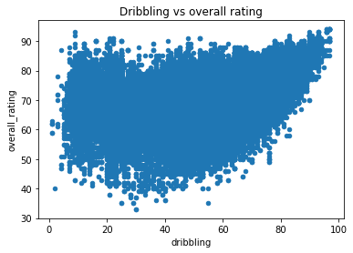

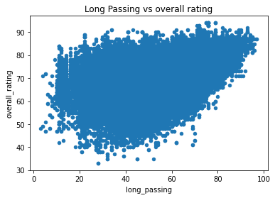

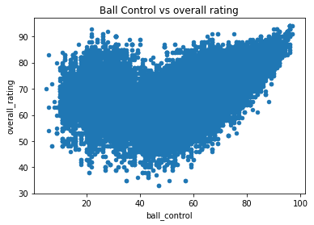

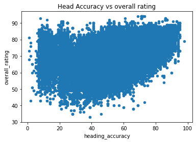

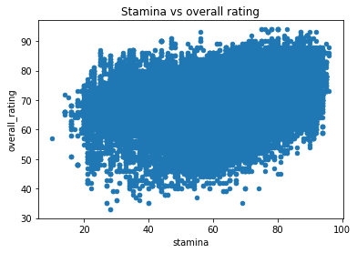

```python
players.plot(x = 'dribbling', y = 'overall_rating',title = 'Dribbling vs overall rating', kind = 'scatter')

players.plot(x = 'long_passing', y = 'overall_rating',title = 'Long Passing vs overall rating', kind = 'scatter')

players.plot(x = 'ball_control', y = 'overall_rating',title = 'Ball Control vs overall rating', kind = 'scatter')

players.plot(x = 'heading_accuracy', y = 'overall_rating',title = 'Head Accuracy vs overall rating', kind = 'scatter')

players.plot(x = 'stamina', y = 'overall_rating',title = 'Stamina vs overall rating', kind = 'scatter')
```

## Limitations and Challenges

One of the most challenging stuff I faced with this dataset is dealing with data that is origianlly taking from SQl, since I don't usually deal with SQL but this was a real wonderful journey.

I had to do so much searching about reading data in Pandas from SQL and how to deal with it.

Also what was challenging is how to merge between the data tables seperately and finding the keys that are common with data tables

Creating new columns to help me with the analysis process was great to code like winner and points_ganied columns in matches dataframe

Eventually, the analysis process is my favourite since I like playing with data so much and come up with various conculsions and plotting results with matplotlib which was abit hard since I don't know to much about it so I had to google alot of stuff

### Conclusion

I managed to end up with some good conclusions and answer to some questions I wanted to know and they are as follows:

[output not shown]